# Machine Learning Project

Lorenzo Tanganelli

19/7/2019

## Github Repository

You can find the entire project (the) R code produced and all results) on this github repo:

- https://github.com/tangalor/Practical-Machine-Learning-Course-Project

## Background of the project

Using devices such as Jawbone Up, Nike FuelBand, and Fitbit it is now possible to collect a large amount of data about personal activity relatively inexpensively. These type of devices are part of the quantified self movement - a group of enthusiasts who take measurements about themselves regularly to improve their health, to find patterns in their behavior, or because they are tech geeks. One thing that people regularly do is quantify how much of a particular activity they do, but they rarely quantify how well they do it. The goal of this project is to use data from accelerometers on the belt, forearm, arm, and dumbbell of 6 participants as they perform barbell lifts correctly and incorrectly 5 different ways.

Six young healthy participants were asked to perform one set of 10 repetitions of the Unilateral Dumbbell Biceps Curl in five different fashions:

- Class A - exactly according to the specification
- Class B - throwing the elbows to the front
- Class C - lifting the dumbbell only halfway
- Class D - lowering the dumbbell only halfway
- Class E - throwing the hips to the front

Class A corresponds to the specified execution of the exercise, while the other 4 classes correspond to common mistakes. Participants were supervised by an experienced weight lifter to make sure the execution complied to the manner they were supposed to simulate. The exercises were performed by six male participants aged between 20-28 years, with little weight lifting experience. Researchers made sure that all participants could easily simulate the mistakes in a safe and controlled manner by using a relatively light dumbbell (1.25kg).

## Data to work on

The training data for this project are available here:

- training data -> https://d396qusza40orc.cloudfront.net/predmachlearn/pml-training.csv
- testing data -> https://d396qusza40orc.cloudfront.net/predmachlearn/pml-testing.csv

The real source of this data is http://groupware.les.inf.puc-rio.br/har. (Please, If you use the document you create for this class for any purpose please cite them as they have been very generous in allowing their data to be used for this kind of assignment.)

## Goal of the project to achieve

The goal of this project is to predict the manner in which subjects did the exercise. This is the “classe” variable in the training set. The model will use the other variables to predict with. This report describes:

- how the model is built
- use of cross validation
- an estimate of expected out of sample error

## Project explanation (inside the code)

This is the commented code produced for the project.

# Loading libraries

Load all the necessary libraries to use common functions and analyze the data.

```
library(tidyverse)
library(vroom)
library(caret)
library(randomForest)
library(rpart)
library(rpart.plot)
library(purrr)

set.seed(999)
```

# Import Dataset

Import dataset to work on.

- **train** is the trainign data
- **test** is the testing data

Then, train and test are both cleaned deleting what it was not necessary.

```r
train <- vroom("C:/Users/LEI00023/Downloads/pml-training.csv", delim = ",",
               na=c("NA","#DIV/0!", ""))
```

```
## * `` -> ...1
```

```
## Observations: 19,622
## Variables: 160
## chr [  4]: user_name, cvtd_timestamp, new_window, classe
## dbl [150]: , raw_timestamp_part_1, raw_timestamp_part_2, num_window, roll_belt, pitch_b...
## lgl [  6]: kurtosis_yaw_belt, skewness_yaw_belt, kurtosis_yaw_dumbbell, skewness_yaw_du...
##
## Call `spec()` for a copy-pastable column specification
```

```r
test <- vroom("C:/Users/LEI00023/Downloads/pml-testing.csv", delim = ",",
              na=c("NA","#DIV/0!", ""))
```

```
## * `` -> ...1
```

```
## Observations: 20
## Variables: 160
## chr [  3]: user_name, cvtd_timestamp, new_window
## dbl [ 57]: , raw_timestamp_part_1, raw_timestamp_part_2, num_window, roll_belt, pitch_b...
## lgl [100]: kurtosis_roll_belt, kurtosis_picth_belt, kurtosis_yaw_belt, skewness_roll_be...
##
## Call `spec()` for a copy-pastable column specification
```

```r
train <- train[,-c(1:7)] %>%
         keep(~sum(is.na(.x))==0) %>%
         mutate(id=row_number(),
                classe = as.factor(classe))


test <- test[,-c(1:7)] %>% keep(~sum(is.na(.x))==0)
```

# Exploratory Data Analysis

Analyzing the data

```r
train_train <- train %>% group_by(classe) %>% sample_frac(size = .80) %>% ungroup()

train_cv <- train %>% anti_join(train_train, by = "id") %>% select(-id)

train_train <- train_train %>% select(-id)

count(train,classe) %>% mutate(prop = n/sum(n))
```

```
## # A tibble: 5 x 3
##   classe     n  prop
##   <fct>  <int> <dbl>
## 1 A       5580 0.284
## 2 B       3797 0.194
## 3 C       3422 0.174
## 4 D       3216 0.164
## 5 E       3607 0.184
```

```r
count(train_train,classe) %>% mutate(prop = n/sum(n))
```

```
## # A tibble: 5 x 3
##   classe     n  prop
##   <fct>  <int> <dbl>
## 1 A       4464 0.284
## 2 B       3038 0.194
## 3 C       2738 0.174
## 4 D       2573 0.164
## 5 E       2886 0.184
```

```r
count(train_cv,classe) %>% mutate(prop = n/sum(n))
```

```
## # A tibble: 5 x 3
##   classe     n  prop
##   <fct>  <int> <dbl>
## 1 A       1116 0.284
## 2 B        759 0.193
## 3 C        684 0.174
## 4 D        643 0.164
## 5 E        721 0.184
```

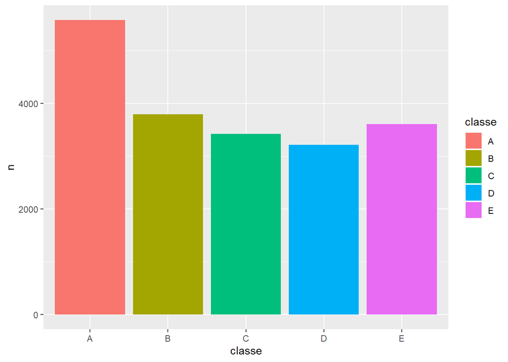

# Applying the “Decision Tree” model

Finding the “Decision tree” accuracy (acc_dt variable).

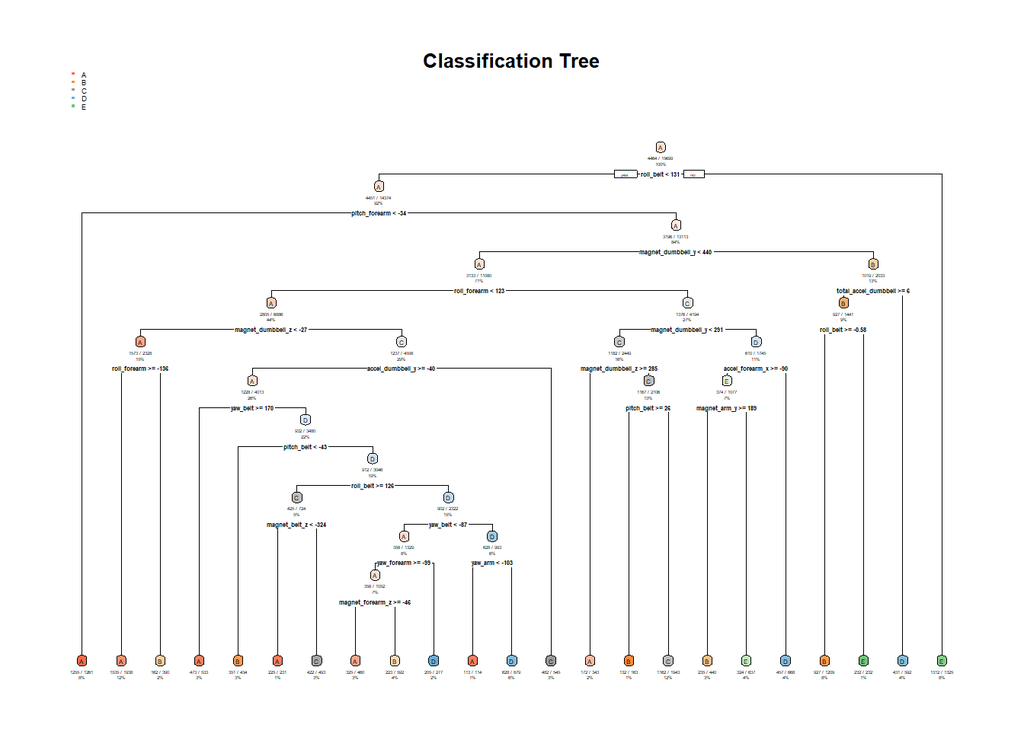

```r
decision_model <- rpart(classe ~ ., data=train_train, method="class") # class perche classificazione

prediction_dt <- predict(decision_model, train_cv, type = "class") # test_preliminare

rpart.plot(decision_model, main="Classification Tree", extra=102, under=TRUE, faclen=0)
```

```r
summary_pred_dt <- data.frame(obs = as.factor(train_cv$classe), predicted = prediction_dt)

acc_dt <-sum(summary_pred_dt$obs==summary_pred_dt$predicted)/nrow(summary_pred_dt)#accuracy

conf_mat_dt<-confusionMatrix(prediction_dt, summary_pred_dt$obs)

conf_mat_dt$table
```

```
##           Reference
## Prediction    A    B    C    D    E
##          A 1017  130   14   36   32
##          B   48  503   92   65  103
##          C   21   46  509  100   74
##          D   17   53   44  415   68
##          E   13   27   25   27  444
```

# Applying the “Random Forest” model with CV

Finding the “Random Forest cross validation” accuracy (acc_cv variable).

```r
control.parms <- trainControl(method="cv", 5)

model_cv <- train(classe ~ ., data=train_train, method="rf",
                  trControl=control.parms)

prediction_cv <- predict(model_cv, train_cv, type = "raw")

summary_pred_cv <- data.frame(obs = as.factor(train_cv$classe), predicted = prediction_cv)

acc_cv <- sum(summary_pred_cv$obs==summary_pred_cv$predicted)/nrow(summary_pred_cv)#accuracy

conf_mat_cv<-confusionMatrix(prediction_cv, summary_pred_cv$obs)

conf_mat_cv$table
```

```
##           Reference
## Prediction    A    B    C    D    E
##          A 1116   10    0    0    0
##          B    0  748    2    0    0
##          C    0    1  681    9    0
##          D    0    0    1  633    1
##          E    0    0    0    1  720
```

# Accuracy Comparison

Compare the accuracy

```r
acc_dt
```

```
## [1] 0.7361713
```

```r
acc_cv
```

```
## [1] 0.9936273
```

Result printed

# Out Of Sample Error

Finding the error on accuracy

```r
1 - acc_dt
```

```
## [1] 0.2638287
```

```r
1 - acc_cv
```

```
## [1] 0.006372674
```

Result printed

# Final Sumbission

This is the final prediction using the testing data. This is the command used

```r
prediction_final <- predict(model_cv, test, type = "raw")

prediction_final
```

```
##  [1] B A B A A E D B A A B C B A E E A B B B
## Levels: A B C D E
```

that generate the final result, printed up here.